# Risk Factor Analysis

## Outcome Variable

**Outcome Variable:** y_rate_len

## Predictor Variables

**Intervention Variable:** impsan

**Adjustment Set:**

unadjusted

## Stratifying Variables

The analysis was stratified on these variable(s):

- agecat
- studyid
- country

## Data Summary

| agecat | studyid | country | impsan | n_cell | n |
| --- | --- | --- | --- | --- | --- |
| 0-3 months | COHORTS | GUATEMALA | 1 | 42 | 445 |
| 0-3 months | COHORTS | GUATEMALA | 0 | 403 | 445 |
| 0-3 months | COHORTS | INDIA | 1 | 1732 | 4660 |
| 0-3 months | COHORTS | INDIA | 0 | 2928 | 4660 |
| 0-3 months | CONTENT | PERU | 1 | 25 | 29 |
| 0-3 months | CONTENT | PERU | 0 | 4 | 29 |
| 0-3 months | MAL-ED | BANGLADESH | 1 | 198 | 236 |
| 0-3 months | MAL-ED | BANGLADESH | 0 | 38 | 236 |
| 0-3 months | MAL-ED | BRAZIL | 1 | 159 | 163 |
| 0-3 months | MAL-ED | BRAZIL | 0 | 4 | 163 |
| 0-3 months | MAL-ED | INDIA | 1 | 80 | 176 |
| 0-3 months | MAL-ED | INDIA | 0 | 96 | 176 |
| 0-3 months | MAL-ED | NEPAL | 1 | 154 | 155 |
| 0-3 months | MAL-ED | NEPAL | 0 | 1 | 155 |
| 0-3 months | MAL-ED | PERU | 1 | 60 | 246 |
| 0-3 months | MAL-ED | PERU | 0 | 186 | 246 |
| 0-3 months | MAL-ED | SOUTH AFRICA | 1 | 2 | 194 |
| 0-3 months | MAL-ED | SOUTH AFRICA | 0 | 192 | 194 |
| 0-3 months | MAL-ED | TANZANIA, UNITED REPUBLIC OF | 1 | 0 | 216 |
| 0-3 months | MAL-ED | TANZANIA, UNITED REPUBLIC OF | 0 | 216 | 216 |
| 0-3 months | NIH-Birth | BANGLADESH | 1 | 218 | 566 |
| 0-3 months | NIH-Birth | BANGLADESH | 0 | 348 | 566 |
| 0-3 months | NIH-Crypto | BANGLADESH | 1 | 626 | 710 |
| 0-3 months | NIH-Crypto | BANGLADESH | 0 | 84 | 710 |
| 0-3 months | PROVIDE | BANGLADESH | 1 | 13 | 13 |
| 0-3 months | PROVIDE | BANGLADESH | 0 | 0 | 13 |
| 3-6 months | COHORTS | GUATEMALA | 1 | 58 | 551 |
| 3-6 months | COHORTS | GUATEMALA | 0 | 493 | 551 |
| 3-6 months | COHORTS | INDIA | 1 | 1770 | 4719 |
| 3-6 months | COHORTS | INDIA | 0 | 2949 | 4719 |

[output cut: 182 more lines]

The following strata were considered:

- agecat: 0-3 months, studyid: COHORTS, country: GUATEMALA
- agecat: 0-3 months, studyid: COHORTS, country: INDIA
- agecat: 0-3 months, studyid: CONTENT, country: PERU
- agecat: 0-3 months, studyid: MAL-ED, country: BANGLADESH
- agecat: 0-3 months, studyid: MAL-ED, country: BRAZIL
- agecat: 0-3 months, studyid: MAL-ED, country: INDIA
- agecat: 0-3 months, studyid: MAL-ED, country: NEPAL
- agecat: 0-3 months, studyid: MAL-ED, country: PERU
- agecat: 0-3 months, studyid: MAL-ED, country: SOUTH AFRICA
- agecat: 0-3 months, studyid: MAL-ED, country: TANZANIA, UNITED REPUBLIC OF
- agecat: 0-3 months, studyid: NIH-Birth, country: BANGLADESH
- agecat: 0-3 months, studyid: NIH-Crypto, country: BANGLADESH
- agecat: 0-3 months, studyid: PROVIDE, country: BANGLADESH
- agecat: 12-15 months, studyid: COHORTS, country: GUATEMALA
- agecat: 12-15 months, studyid: CONTENT, country: PERU
- agecat: 12-15 months, studyid: LCNI-5, country: MALAWI
- agecat: 12-15 months, studyid: MAL-ED, country: BANGLADESH
- agecat: 12-15 months, studyid: MAL-ED, country: BRAZIL
- agecat: 12-15 months, studyid: MAL-ED, country: INDIA
- agecat: 12-15 months, studyid: MAL-ED, country: NEPAL
- agecat: 12-15 months, studyid: MAL-ED, country: PERU
- agecat: 12-15 months, studyid: MAL-ED, country: SOUTH AFRICA
- agecat: 12-15 months, studyid: MAL-ED, country: TANZANIA, UNITED REPUBLIC OF
- agecat: 12-15 months, studyid: NIH-Birth, country: BANGLADESH
- agecat: 12-15 months, studyid: NIH-Crypto, country: BANGLADESH
- agecat: 12-15 months, studyid: PROVIDE, country: BANGLADESH
- agecat: 15-18 months, studyid: COHORTS, country: GUATEMALA
- agecat: 15-18 months, studyid: CONTENT, country: PERU
- agecat: 15-18 months, studyid: LCNI-5, country: MALAWI
- agecat: 15-18 months, studyid: MAL-ED, country: BANGLADESH
- agecat: 15-18 months, studyid: MAL-ED, country: BRAZIL
- agecat: 15-18 months, studyid: MAL-ED, country: INDIA
- agecat: 15-18 months, studyid: MAL-ED, country: NEPAL
- agecat: 15-18 months, studyid: MAL-ED, country: PERU
- agecat: 15-18 months, studyid: MAL-ED, country: SOUTH AFRICA
- agecat: 15-18 months, studyid: MAL-ED, country: TANZANIA, UNITED REPUBLIC OF
- agecat: 15-18 months, studyid: NIH-Birth, country: BANGLADESH
- agecat: 15-18 months, studyid: NIH-Crypto, country: BANGLADESH
- agecat: 15-18 months, studyid: PROVIDE, country: BANGLADESH
- agecat: 18-21 months, studyid: COHORTS, country: GUATEMALA
- agecat: 18-21 months, studyid: CONTENT, country: PERU
- agecat: 18-21 months, studyid: LCNI-5, country: MALAWI
- agecat: 18-21 months, studyid: MAL-ED, country: BANGLADESH
- agecat: 18-21 months, studyid: MAL-ED, country: BRAZIL
- agecat: 18-21 months, studyid: MAL-ED, country: INDIA
- agecat: 18-21 months, studyid: MAL-ED, country: NEPAL
- agecat: 18-21 months, studyid: MAL-ED, country: PERU
- agecat: 18-21 months, studyid: MAL-ED, country: SOUTH AFRICA
- agecat: 18-21 months, studyid: MAL-ED, country: TANZANIA, UNITED REPUBLIC OF
- agecat: 18-21 months, studyid: NIH-Birth, country: BANGLADESH
- agecat: 18-21 months, studyid: NIH-Crypto, country: BANGLADESH
- agecat: 18-21 months, studyid: PROVIDE, country: BANGLADESH
- agecat: 21-24 months, studyid: COHORTS, country: GUATEMALA
- agecat: 21-24 months, studyid: CONTENT, country: PERU
- agecat: 21-24 months, studyid: LCNI-5, country: MALAWI
- agecat: 21-24 months, studyid: MAL-ED, country: BANGLADESH
- agecat: 21-24 months, studyid: MAL-ED, country: BRAZIL
- agecat: 21-24 months, studyid: MAL-ED, country: INDIA
- agecat: 21-24 months, studyid: MAL-ED, country: NEPAL
- agecat: 21-24 months, studyid: MAL-ED, country: PERU
- agecat: 21-24 months, studyid: MAL-ED, country: SOUTH AFRICA
- agecat: 21-24 months, studyid: MAL-ED, country: TANZANIA, UNITED REPUBLIC OF
- agecat: 21-24 months, studyid: NIH-Birth, country: BANGLADESH
- agecat: 21-24 months, studyid: NIH-Crypto, country: BANGLADESH
- agecat: 21-24 months, studyid: PROVIDE, country: BANGLADESH
- agecat: 3-6 months, studyid: COHORTS, country: GUATEMALA
- agecat: 3-6 months, studyid: COHORTS, country: INDIA
- agecat: 3-6 months, studyid: CONTENT, country: PERU
- agecat: 3-6 months, studyid: MAL-ED, country: BANGLADESH
- agecat: 3-6 months, studyid: MAL-ED, country: BRAZIL
- agecat: 3-6 months, studyid: MAL-ED, country: INDIA
- agecat: 3-6 months, studyid: MAL-ED, country: NEPAL
- agecat: 3-6 months, studyid: MAL-ED, country: PERU
- agecat: 3-6 months, studyid: MAL-ED, country: SOUTH AFRICA
- agecat: 3-6 months, studyid: MAL-ED, country: TANZANIA, UNITED REPUBLIC OF
- agecat: 3-6 months, studyid: NIH-Birth, country: BANGLADESH
- agecat: 3-6 months, studyid: NIH-Crypto, country: BANGLADESH
- agecat: 3-6 months, studyid: PROVIDE, country: BANGLADESH
- agecat: 6-9 months, studyid: COHORTS, country: GUATEMALA
- agecat: 6-9 months, studyid: COHORTS, country: INDIA
- agecat: 6-9 months, studyid: CONTENT, country: PERU
- agecat: 6-9 months, studyid: LCNI-5, country: MALAWI
- agecat: 6-9 months, studyid: MAL-ED, country: BANGLADESH
- agecat: 6-9 months, studyid: MAL-ED, country: BRAZIL
- agecat: 6-9 months, studyid: MAL-ED, country: INDIA
- agecat: 6-9 months, studyid: MAL-ED, country: NEPAL
- agecat: 6-9 months, studyid: MAL-ED, country: PERU
- agecat: 6-9 months, studyid: MAL-ED, country: SOUTH AFRICA
- agecat: 6-9 months, studyid: MAL-ED, country: TANZANIA, UNITED REPUBLIC OF
- agecat: 6-9 months, studyid: NIH-Birth, country: BANGLADESH
- agecat: 6-9 months, studyid: NIH-Crypto, country: BANGLADESH
- agecat: 6-9 months, studyid: PROVIDE, country: BANGLADESH
- agecat: 9-12 months, studyid: COHORTS, country: GUATEMALA
- agecat: 9-12 months, studyid: COHORTS, country: INDIA
- agecat: 9-12 months, studyid: CONTENT, country: PERU
- agecat: 9-12 months, studyid: LCNI-5, country: MALAWI
- agecat: 9-12 months, studyid: MAL-ED, country: BANGLADESH
- agecat: 9-12 months, studyid: MAL-ED, country: BRAZIL
- agecat: 9-12 months, studyid: MAL-ED, country: INDIA
- agecat: 9-12 months, studyid: MAL-ED, country: NEPAL
- agecat: 9-12 months, studyid: MAL-ED, country: PERU
- agecat: 9-12 months, studyid: MAL-ED, country: SOUTH AFRICA
- agecat: 9-12 months, studyid: MAL-ED, country: TANZANIA, UNITED REPUBLIC OF
- agecat: 9-12 months, studyid: NIH-Birth, country: BANGLADESH
- agecat: 9-12 months, studyid: NIH-Crypto, country: BANGLADESH
- agecat: 9-12 months, studyid: PROVIDE, country: BANGLADESH

### Dropped Strata

Some strata were dropped due to rare outcomes:

- agecat: 0-3 months, studyid: CONTENT, country: PERU
- agecat: 0-3 months, studyid: MAL-ED, country: BRAZIL
- agecat: 0-3 months, studyid: MAL-ED, country: NEPAL
- agecat: 0-3 months, studyid: MAL-ED, country: SOUTH AFRICA
- agecat: 0-3 months, studyid: MAL-ED, country: TANZANIA, UNITED REPUBLIC OF
- agecat: 0-3 months, studyid: PROVIDE, country: BANGLADESH
- agecat: 3-6 months, studyid: MAL-ED, country: BRAZIL
- agecat: 3-6 months, studyid: MAL-ED, country: NEPAL
- agecat: 3-6 months, studyid: MAL-ED, country: SOUTH AFRICA
- agecat: 3-6 months, studyid: MAL-ED, country: TANZANIA, UNITED REPUBLIC OF
- agecat: 3-6 months, studyid: PROVIDE, country: BANGLADESH
- agecat: 6-9 months, studyid: LCNI-5, country: MALAWI
- agecat: 6-9 months, studyid: MAL-ED, country: BRAZIL
- agecat: 6-9 months, studyid: MAL-ED, country: NEPAL
- agecat: 6-9 months, studyid: MAL-ED, country: SOUTH AFRICA
- agecat: 6-9 months, studyid: MAL-ED, country: TANZANIA, UNITED REPUBLIC OF
- agecat: 6-9 months, studyid: PROVIDE, country: BANGLADESH
- agecat: 9-12 months, studyid: LCNI-5, country: MALAWI
- agecat: 9-12 months, studyid: MAL-ED, country: BRAZIL
- agecat: 9-12 months, studyid: MAL-ED, country: NEPAL
- agecat: 9-12 months, studyid: MAL-ED, country: SOUTH AFRICA
- agecat: 9-12 months, studyid: MAL-ED, country: TANZANIA, UNITED REPUBLIC OF
- agecat: 9-12 months, studyid: PROVIDE, country: BANGLADESH
- agecat: 12-15 months, studyid: LCNI-5, country: MALAWI
- agecat: 12-15 months, studyid: MAL-ED, country: BRAZIL
- agecat: 12-15 months, studyid: MAL-ED, country: NEPAL
- agecat: 12-15 months, studyid: MAL-ED, country: SOUTH AFRICA
- agecat: 12-15 months, studyid: MAL-ED, country: TANZANIA, UNITED REPUBLIC OF
- agecat: 12-15 months, studyid: PROVIDE, country: BANGLADESH
- agecat: 15-18 months, studyid: LCNI-5, country: MALAWI
- agecat: 15-18 months, studyid: MAL-ED, country: BRAZIL
- agecat: 15-18 months, studyid: MAL-ED, country: NEPAL
- agecat: 15-18 months, studyid: MAL-ED, country: SOUTH AFRICA
- agecat: 15-18 months, studyid: MAL-ED, country: TANZANIA, UNITED REPUBLIC OF
- agecat: 15-18 months, studyid: PROVIDE, country: BANGLADESH
- agecat: 18-21 months, studyid: LCNI-5, country: MALAWI
- agecat: 18-21 months, studyid: MAL-ED, country: BRAZIL
- agecat: 18-21 months, studyid: MAL-ED, country: NEPAL
- agecat: 18-21 months, studyid: MAL-ED, country: SOUTH AFRICA
- agecat: 18-21 months, studyid: MAL-ED, country: TANZANIA, UNITED REPUBLIC OF
- agecat: 18-21 months, studyid: PROVIDE, country: BANGLADESH
- agecat: 21-24 months, studyid: CONTENT, country: PERU
- agecat: 21-24 months, studyid: LCNI-5, country: MALAWI
- agecat: 21-24 months, studyid: MAL-ED, country: BRAZIL
- agecat: 21-24 months, studyid: MAL-ED, country: NEPAL
- agecat: 21-24 months, studyid: MAL-ED, country: SOUTH AFRICA
- agecat: 21-24 months, studyid: MAL-ED, country: TANZANIA, UNITED REPUBLIC OF
- agecat: 21-24 months, studyid: PROVIDE, country: BANGLADESH

## Methods Detail

We’re interested in the causal parameters $E[Y_a]$ for all values of $a \in \mathcal{A}$. These parameters represent the mean outcome if, possibly contrary to fact, we intervened to set all units to have $A=a$. Under the randomization and positivity assumptions, these are identified by the statistical parameters $\psi_a=E_W[E_{Y|A,W}(Y|A=a,W)]$. In addition, we’re interested in the mean of $Y$, $E[Y]$ under no intervention (the observed mean). We will estimate these parameters by using SuperLearner to fit the relevant likelihood factors – $E_{Y|A,W}(Y|A=a,W)$ and $p(A=a|W)$, and then updating our likelihood fit using a joint TMLE.

For unadjusted analyses ($W=\{\}$), initial likelihoods were estimated using Lrnr_glm to estimate the simple $E(Y|A)$ and Lrnr_mean to estimate $p(A)$. For adjusted analyses, a small library containing Lrnr_glmnet, Lrnr_xgboost, and Lrnr_mean was used.

Having estimated these parameters, we will then use the delta method to estimate relative risks and attributable risks relative to a prespecified baseline level of $A$.

# Results Detail

## Results Plots

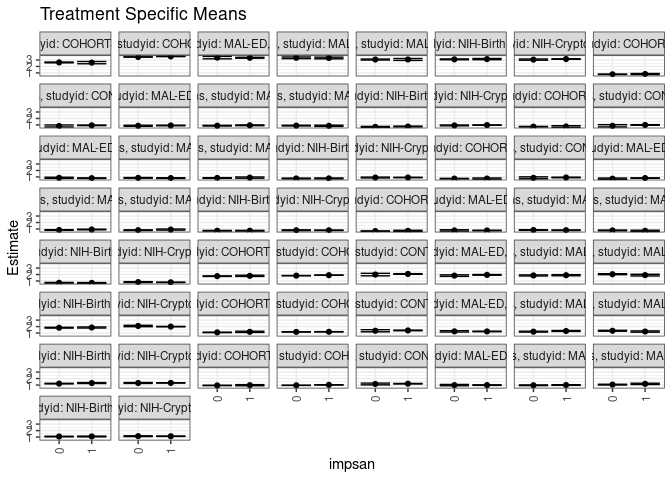

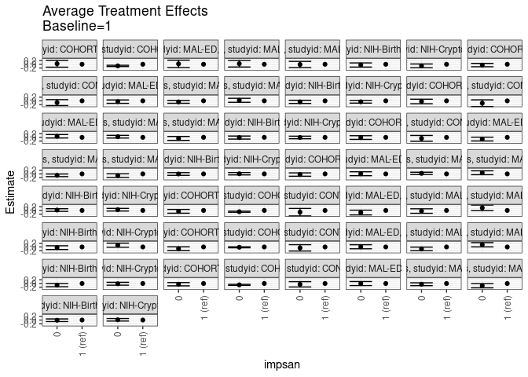

[figure not shown]

## Results Table

### Parameter: TSM

| agecat | studyid | country | intervention_level | baseline_level | estimate | ci_lower | ci_upper |
| --- | --- | --- | --- | --- | --- | --- | --- |
| 0-3 months | COHORTS | GUATEMALA | 1 | NA | 2.5901331 | 2.4127886 | 2.7674775 |
| 0-3 months | COHORTS | GUATEMALA | 0 | NA | 2.6206125 | 2.5632601 | 2.6779649 |
| 0-3 months | COHORTS | INDIA | 1 | NA | 3.5481583 | 3.5212218 | 3.5750948 |
| 0-3 months | COHORTS | INDIA | 0 | NA | 3.4616508 | 3.4404929 | 3.4828087 |
| 0-3 months | MAL-ED | BANGLADESH | 1 | NA | 3.3433575 | 3.2740607 | 3.4126544 |
| 0-3 months | MAL-ED | BANGLADESH | 0 | NA | 3.3660422 | 3.1779810 | 3.5541035 |
| 0-3 months | MAL-ED | INDIA | 1 | NA | 3.3089974 | 3.1824588 | 3.4355360 |
| 0-3 months | MAL-ED | INDIA | 0 | NA | 3.3397158 | 3.2134135 | 3.4660181 |
| 0-3 months | MAL-ED | PERU | 1 | NA | 3.0809572 | 2.9306808 | 3.2312335 |
| 0-3 months | MAL-ED | PERU | 0 | NA | 3.0702715 | 2.9966077 | 3.1439353 |
| 0-3 months | NIH-Birth | BANGLADESH | 1 | NA | 3.1337131 | 3.0419795 | 3.2254467 |
| 0-3 months | NIH-Birth | BANGLADESH | 0 | NA | 3.0951641 | 3.0300695 | 3.1602586 |
| 0-3 months | NIH-Crypto | BANGLADESH | 1 | NA | 3.1437822 | 3.1042912 | 3.1832733 |
| 0-3 months | NIH-Crypto | BANGLADESH | 0 | NA | 3.0571620 | 2.9623341 | 3.1519899 |
| 3-6 months | COHORTS | GUATEMALA | 1 | NA | 1.7971907 | 1.7032865 | 1.8910950 |
| 3-6 months | COHORTS | GUATEMALA | 0 | NA | 1.7490522 | 1.7086996 | 1.7894049 |
| 3-6 months | COHORTS | INDIA | 1 | NA | 1.9005768 | 1.8778511 | 1.9233024 |
| 3-6 months | COHORTS | INDIA | 0 | NA | 1.8311816 | 1.8134779 | 1.8488852 |
| 3-6 months | CONTENT | PERU | 1 | NA | 2.0902904 | 2.0409885 | 2.1395922 |
| 3-6 months | CONTENT | PERU | 0 | NA | 1.9969515 | 1.8006964 | 2.1932065 |
| 3-6 months | MAL-ED | BANGLADESH | 1 | NA | 1.9464121 | 1.8912215 | 2.0016026 |
| 3-6 months | MAL-ED | BANGLADESH | 0 | NA | 1.8323021 | 1.7157969 | 1.9488073 |
| 3-6 months | MAL-ED | INDIA | 1 | NA | 1.8953711 | 1.8060981 | 1.9846440 |
| 3-6 months | MAL-ED | INDIA | 0 | NA | 1.8632922 | 1.7804571 | 1.9461273 |
| 3-6 months | MAL-ED | PERU | 1 | NA | 1.9119001 | 1.7822245 | 2.0415756 |
| 3-6 months | MAL-ED | PERU | 0 | NA | 2.0513603 | 1.9748147 | 2.1279060 |
| 3-6 months | NIH-Birth | BANGLADESH | 1 | NA | 1.8552555 | 1.7728284 | 1.9376825 |
| 3-6 months | NIH-Birth | BANGLADESH | 0 | NA | 1.8189448 | 1.7602643 | 1.8776254 |
| 3-6 months | NIH-Crypto | BANGLADESH | 1 | NA | 1.9909411 | 1.9526659 | 2.0292164 |
| 3-6 months | NIH-Crypto | BANGLADESH | 0 | NA | 2.0882905 | 1.9837467 | 2.1928344 |

[output cut: 86 more lines]

### Parameter: E(Y)

| agecat | studyid | country | intervention_level | baseline_level | estimate | ci_lower | ci_upper |
| --- | --- | --- | --- | --- | --- | --- | --- |
| 0-3 months | COHORTS | GUATEMALA | NA | NA | 2.6177358 | 2.5631597 | 2.6723119 |
| 0-3 months | COHORTS | INDIA | NA | NA | 3.4938034 | 3.4771179 | 3.5104888 |
| 0-3 months | MAL-ED | BANGLADESH | NA | NA | 3.3470101 | 3.2814494 | 3.4125709 |
| 0-3 months | MAL-ED | INDIA | NA | NA | 3.3257529 | 3.2359780 | 3.4155278 |
| 0-3 months | MAL-ED | PERU | NA | NA | 3.0728777 | 3.0062000 | 3.1395554 |
| 0-3 months | NIH-Birth | BANGLADESH | NA | NA | 3.1100116 | 3.0566021 | 3.1634210 |
| 0-3 months | NIH-Crypto | BANGLADESH | NA | NA | 3.1335342 | 3.0968946 | 3.1701738 |
| 3-6 months | COHORTS | GUATEMALA | NA | NA | 1.7541195 | 1.7166655 | 1.7915734 |
| 3-6 months | COHORTS | INDIA | NA | NA | 1.8572103 | 1.8432112 | 1.8712094 |
| 3-6 months | CONTENT | PERU | NA | NA | 2.0841841 | 2.0362519 | 2.1321163 |
| 3-6 months | MAL-ED | BANGLADESH | NA | NA | 1.9276407 | 1.8774065 | 1.9778750 |
| 3-6 months | MAL-ED | INDIA | NA | NA | 1.8780654 | 1.8173074 | 1.9388233 |
| 3-6 months | MAL-ED | PERU | NA | NA | 2.0175680 | 1.9512051 | 2.0839310 |
| 3-6 months | NIH-Birth | BANGLADESH | NA | NA | 1.8326915 | 1.7846731 | 1.8807099 |
| 3-6 months | NIH-Crypto | BANGLADESH | NA | NA | 2.0027540 | 1.9667312 | 2.0387768 |
| 6-9 months | COHORTS | GUATEMALA | NA | NA | 1.1046168 | 1.0728025 | 1.1364310 |
| 6-9 months | COHORTS | INDIA | NA | NA | 1.1818282 | 1.1689263 | 1.1947301 |
| 6-9 months | CONTENT | PERU | NA | NA | 1.3974236 | 1.3502187 | 1.4446285 |
| 6-9 months | MAL-ED | BANGLADESH | NA | NA | 1.2480451 | 1.2083209 | 1.2877694 |
| 6-9 months | MAL-ED | INDIA | NA | NA | 1.2581259 | 1.2101884 | 1.3060633 |
| 6-9 months | MAL-ED | PERU | NA | NA | 1.3204373 | 1.2649539 | 1.3759207 |
| 6-9 months | NIH-Birth | BANGLADESH | NA | NA | 1.2555950 | 1.2150667 | 1.2961234 |
| 6-9 months | NIH-Crypto | BANGLADESH | NA | NA | 1.3277672 | 1.2982110 | 1.3573234 |
| 9-12 months | COHORTS | GUATEMALA | NA | NA | 0.9427431 | 0.9140297 | 0.9714566 |
| 9-12 months | COHORTS | INDIA | NA | NA | 0.9844431 | 0.9705367 | 0.9983496 |
| 9-12 months | CONTENT | PERU | NA | NA | 1.2048768 | 1.1650186 | 1.2447350 |
| 9-12 months | MAL-ED | BANGLADESH | NA | NA | 0.9896446 | 0.9509752 | 1.0283140 |
| 9-12 months | MAL-ED | INDIA | NA | NA | 0.9810598 | 0.9425271 | 1.0195925 |
| 9-12 months | MAL-ED | PERU | NA | NA | 1.0938158 | 1.0421876 | 1.1454440 |
| 9-12 months | NIH-Birth | BANGLADESH | NA | NA | 1.0885809 | 1.0534446 | 1.1237171 |
| 9-12 months | NIH-Crypto | BANGLADESH | NA | NA | 1.1253061 | 1.0988172 | 1.1517949 |
| 12-15 months | COHORTS | GUATEMALA | NA | NA | 0.7899732 | 0.7616006 | 0.8183457 |
| 12-15 months | CONTENT | PERU | NA | NA | 0.9291443 | 0.8867697 | 0.9715190 |
| 12-15 months | MAL-ED | BANGLADESH | NA | NA | 0.9141004 | 0.8737459 | 0.9544550 |
| 12-15 months | MAL-ED | INDIA | NA | NA | 0.9129447 | 0.8748557 | 0.9510337 |
| 12-15 months | MAL-ED | PERU | NA | NA | 0.8895957 | 0.8424004 | 0.9367911 |
| 12-15 months | NIH-Birth | BANGLADESH | NA | NA | 0.7241623 | 0.6797013 | 0.7686233 |
| 12-15 months | NIH-Crypto | BANGLADESH | NA | NA | 0.9714857 | 0.9466423 | 0.9963290 |
| 15-18 months | COHORTS | GUATEMALA | NA | NA | 0.7357057 | 0.7024388 | 0.7689726 |
| 15-18 months | CONTENT | PERU | NA | NA | 0.9860231 | 0.9406097 | 1.0314365 |
| 15-18 months | MAL-ED | BANGLADESH | NA | NA | 0.8241226 | 0.7871907 | 0.8610544 |
| 15-18 months | MAL-ED | INDIA | NA | NA | 0.8461081 | 0.8096109 | 0.8826053 |
| 15-18 months | MAL-ED | PERU | NA | NA | 0.8582871 | 0.8154498 | 0.9011244 |
| 15-18 months | NIH-Birth | BANGLADESH | NA | NA | 0.7727719 | 0.7325606 | 0.8129832 |
| 15-18 months | NIH-Crypto | BANGLADESH | NA | NA | 0.9162288 | 0.8930973 | 0.9393604 |
| 18-21 months | COHORTS | GUATEMALA | NA | NA | 0.7453230 | 0.7139167 | 0.7767294 |
| 18-21 months | CONTENT | PERU | NA | NA | 0.9146338 | 0.8709588 | 0.9583088 |
| 18-21 months | MAL-ED | BANGLADESH | NA | NA | 0.8133847 | 0.7790076 | 0.8477619 |
| 18-21 months | MAL-ED | INDIA | NA | NA | 0.8786990 | 0.8431802 | 0.9142178 |
| 18-21 months | MAL-ED | PERU | NA | NA | 0.8405408 | 0.7957138 | 0.8853678 |
| 18-21 months | NIH-Birth | BANGLADESH | NA | NA | 0.7291468 | 0.6930874 | 0.7652062 |
| 18-21 months | NIH-Crypto | BANGLADESH | NA | NA | 0.7977951 | 0.7741689 | 0.8214214 |
| 21-24 months | COHORTS | GUATEMALA | NA | NA | 0.6771703 | 0.6513485 | 0.7029921 |
| 21-24 months | MAL-ED | BANGLADESH | NA | NA | 0.7694183 | 0.7339448 | 0.8048918 |
| 21-24 months | MAL-ED | INDIA | NA | NA | 0.8256267 | 0.7945621 | 0.8566913 |
| 21-24 months | MAL-ED | PERU | NA | NA | 0.7622936 | 0.7156467 | 0.8089404 |
| 21-24 months | NIH-Birth | BANGLADESH | NA | NA | 0.7172178 | 0.6817161 | 0.7527194 |
| 21-24 months | NIH-Crypto | BANGLADESH | NA | NA | 0.8010871 | 0.7761614 | 0.8260128 |

### Parameter: ATE

| agecat | studyid | country | intervention_level | baseline_level | estimate | ci_lower | ci_upper |
| --- | --- | --- | --- | --- | --- | --- | --- |
| 0-3 months | COHORTS | GUATEMALA | 1 | 1 | 0.0000000 | 0.0000000 | 0.0000000 |
| 0-3 months | COHORTS | GUATEMALA | 0 | 1 | 0.0304794 | -0.1559083 | 0.2168670 |
| 0-3 months | COHORTS | INDIA | 1 | 1 | 0.0000000 | 0.0000000 | 0.0000000 |
| 0-3 months | COHORTS | INDIA | 0 | 1 | -0.0865075 | -0.1207600 | -0.0522550 |
| 0-3 months | MAL-ED | BANGLADESH | 1 | 1 | 0.0000000 | 0.0000000 | 0.0000000 |
| 0-3 months | MAL-ED | BANGLADESH | 0 | 1 | 0.0226847 | -0.1777375 | 0.2231070 |
| 0-3 months | MAL-ED | INDIA | 1 | 1 | 0.0000000 | 0.0000000 | 0.0000000 |
| 0-3 months | MAL-ED | INDIA | 0 | 1 | 0.0307184 | -0.1480672 | 0.2095040 |
| 0-3 months | MAL-ED | PERU | 1 | 1 | 0.0000000 | 0.0000000 | 0.0000000 |
| 0-3 months | MAL-ED | PERU | 0 | 1 | -0.0106857 | -0.1780456 | 0.1566742 |
| 0-3 months | NIH-Birth | BANGLADESH | 1 | 1 | 0.0000000 | 0.0000000 | 0.0000000 |
| 0-3 months | NIH-Birth | BANGLADESH | 0 | 1 | -0.0385490 | -0.1510317 | 0.0739336 |
| 0-3 months | NIH-Crypto | BANGLADESH | 1 | 1 | 0.0000000 | 0.0000000 | 0.0000000 |
| 0-3 months | NIH-Crypto | BANGLADESH | 0 | 1 | -0.0866202 | -0.1893425 | 0.0161021 |
| 3-6 months | COHORTS | GUATEMALA | 1 | 1 | 0.0000000 | 0.0000000 | 0.0000000 |
| 3-6 months | COHORTS | GUATEMALA | 0 | 1 | -0.0481385 | -0.1503458 | 0.0540689 |
| 3-6 months | COHORTS | INDIA | 1 | 1 | 0.0000000 | 0.0000000 | 0.0000000 |
| 3-6 months | COHORTS | INDIA | 0 | 1 | -0.0693952 | -0.0982027 | -0.0405877 |
| 3-6 months | CONTENT | PERU | 1 | 1 | 0.0000000 | 0.0000000 | 0.0000000 |
| 3-6 months | CONTENT | PERU | 0 | 1 | -0.0933389 | -0.2956918 | 0.1090140 |
| 3-6 months | MAL-ED | BANGLADESH | 1 | 1 | 0.0000000 | 0.0000000 | 0.0000000 |
| 3-6 months | MAL-ED | BANGLADESH | 0 | 1 | -0.1141099 | -0.2430264 | 0.0148065 |
| 3-6 months | MAL-ED | INDIA | 1 | 1 | 0.0000000 | 0.0000000 | 0.0000000 |
| 3-6 months | MAL-ED | INDIA | 0 | 1 | -0.0320788 | -0.1538627 | 0.0897050 |
| 3-6 months | MAL-ED | PERU | 1 | 1 | 0.0000000 | 0.0000000 | 0.0000000 |
| 3-6 months | MAL-ED | PERU | 0 | 1 | 0.1394603 | -0.0111219 | 0.2900424 |
| 3-6 months | NIH-Birth | BANGLADESH | 1 | 1 | 0.0000000 | 0.0000000 | 0.0000000 |
| 3-6 months | NIH-Birth | BANGLADESH | 0 | 1 | -0.0363106 | -0.1374918 | 0.0648705 |
| 3-6 months | NIH-Crypto | BANGLADESH | 1 | 1 | 0.0000000 | 0.0000000 | 0.0000000 |
| 3-6 months | NIH-Crypto | BANGLADESH | 0 | 1 | 0.0973494 | -0.0139808 | 0.2086796 |

[output cut: 86 more lines]

### Parameter: PAR

| agecat | studyid | country | intervention_level | baseline_level | estimate | ci_lower | ci_upper |
| --- | --- | --- | --- | --- | --- | --- | --- |
| 0-3 months | COHORTS | GUATEMALA | 1 | NA | 0.0276027 | -0.1411954 | 0.1964007 |
| 0-3 months | COHORTS | INDIA | 1 | NA | -0.0543549 | -0.0759101 | -0.0327997 |
| 0-3 months | MAL-ED | BANGLADESH | 1 | NA | 0.0036526 | -0.0286364 | 0.0359416 |
| 0-3 months | MAL-ED | INDIA | 1 | NA | 0.0167555 | -0.0807902 | 0.1143012 |
| 0-3 months | MAL-ED | PERU | 1 | NA | -0.0080794 | -0.1346211 | 0.1184623 |
| 0-3 months | NIH-Birth | BANGLADESH | 1 | NA | -0.0237015 | -0.0928778 | 0.0454747 |
| 0-3 months | NIH-Crypto | BANGLADESH | 1 | NA | -0.0102480 | -0.0225743 | 0.0020783 |
| 3-6 months | COHORTS | GUATEMALA | 1 | NA | -0.0430713 | -0.1345283 | 0.0483857 |
| 3-6 months | COHORTS | INDIA | 1 | NA | -0.0433665 | -0.0613944 | -0.0253386 |
| 3-6 months | CONTENT | PERU | 1 | NA | -0.0061063 | -0.0197023 | 0.0074898 |
| 3-6 months | MAL-ED | BANGLADESH | 1 | NA | -0.0187713 | -0.0406718 | 0.0031291 |
| 3-6 months | MAL-ED | INDIA | 1 | NA | -0.0173057 | -0.0830378 | 0.0484264 |
| 3-6 months | MAL-ED | PERU | 1 | NA | 0.1056680 | -0.0086588 | 0.2199948 |
| 3-6 months | NIH-Birth | BANGLADESH | 1 | NA | -0.0225640 | -0.0854576 | 0.0403297 |
| 3-6 months | NIH-Crypto | BANGLADESH | 1 | NA | 0.0118129 | -0.0019052 | 0.0255310 |
| 6-9 months | COHORTS | GUATEMALA | 1 | NA | -0.0819728 | -0.1707502 | 0.0068046 |
| 6-9 months | COHORTS | INDIA | 1 | NA | -0.0107131 | -0.0271979 | 0.0057718 |
| 6-9 months | CONTENT | PERU | 1 | NA | -0.0032081 | -0.0144674 | 0.0080511 |
| 6-9 months | MAL-ED | BANGLADESH | 1 | NA | 0.0018154 | -0.0168083 | 0.0204390 |
| 6-9 months | MAL-ED | INDIA | 1 | NA | -0.0555160 | -0.1078233 | -0.0032088 |
| 6-9 months | MAL-ED | PERU | 1 | NA | 0.0911969 | 0.0032987 | 0.1790951 |
| 6-9 months | NIH-Birth | BANGLADESH | 1 | NA | -0.0530073 | -0.1054373 | -0.0005772 |
| 6-9 months | NIH-Crypto | BANGLADESH | 1 | NA | -0.0018167 | -0.0119665 | 0.0083330 |
| 9-12 months | COHORTS | GUATEMALA | 1 | NA | -0.0342189 | -0.1140352 | 0.0455975 |
| 9-12 months | COHORTS | INDIA | 1 | NA | -0.0442922 | -0.0615046 | -0.0270797 |
| 9-12 months | CONTENT | PERU | 1 | NA | -0.0028368 | -0.0123988 | 0.0067252 |
| 9-12 months | MAL-ED | BANGLADESH | 1 | NA | -0.0004369 | -0.0173170 | 0.0164432 |
| 9-12 months | MAL-ED | INDIA | 1 | NA | -0.0208948 | -0.0622682 | 0.0204786 |
| 9-12 months | MAL-ED | PERU | 1 | NA | -0.0926514 | -0.1804866 | -0.0048162 |
| 9-12 months | NIH-Birth | BANGLADESH | 1 | NA | -0.0070209 | -0.0505544 | 0.0365126 |
| 9-12 months | NIH-Crypto | BANGLADESH | 1 | NA | 0.0017702 | -0.0072733 | 0.0108137 |
| 12-15 months | COHORTS | GUATEMALA | 1 | NA | -0.0389412 | -0.1203313 | 0.0424489 |
| 12-15 months | CONTENT | PERU | 1 | NA | -0.0062477 | -0.0173119 | 0.0048165 |
| 12-15 months | MAL-ED | BANGLADESH | 1 | NA | -0.0067907 | -0.0207367 | 0.0071553 |
| 12-15 months | MAL-ED | INDIA | 1 | NA | -0.0311798 | -0.0724352 | 0.0100757 |
| 12-15 months | MAL-ED | PERU | 1 | NA | 0.0214245 | -0.0611216 | 0.1039706 |
| 12-15 months | NIH-Birth | BANGLADESH | 1 | NA | -0.0340576 | -0.0862595 | 0.0181442 |
| 12-15 months | NIH-Crypto | BANGLADESH | 1 | NA | -0.0069972 | -0.0167792 | 0.0027847 |
| 15-18 months | COHORTS | GUATEMALA | 1 | NA | -0.0302644 | -0.1408691 | 0.0803404 |
| 15-18 months | CONTENT | PERU | 1 | NA | -0.0088133 | -0.0220863 | 0.0044596 |
| 15-18 months | MAL-ED | BANGLADESH | 1 | NA | 0.0091623 | -0.0057793 | 0.0241040 |
| 15-18 months | MAL-ED | INDIA | 1 | NA | 0.0191785 | -0.0195920 | 0.0579490 |
| 15-18 months | MAL-ED | PERU | 1 | NA | -0.0435839 | -0.1243442 | 0.0371764 |
| 15-18 months | NIH-Birth | BANGLADESH | 1 | NA | -0.0060949 | -0.0552396 | 0.0430498 |
| 15-18 months | NIH-Crypto | BANGLADESH | 1 | NA | -0.0009220 | -0.0108427 | 0.0089986 |
| 18-21 months | COHORTS | GUATEMALA | 1 | NA | -0.0090040 | -0.0990853 | 0.0810774 |
| 18-21 months | CONTENT | PERU | 1 | NA | -0.0034599 | -0.0138173 | 0.0068974 |
| 18-21 months | MAL-ED | BANGLADESH | 1 | NA | -0.0132430 | -0.0285474 | 0.0020614 |
| 18-21 months | MAL-ED | INDIA | 1 | NA | -0.0410844 | -0.0793156 | -0.0028533 |
| 18-21 months | MAL-ED | PERU | 1 | NA | -0.0694141 | -0.1425421 | 0.0037139 |
| 18-21 months | NIH-Birth | BANGLADESH | 1 | NA | -0.0024559 | -0.0466115 | 0.0416997 |
| 18-21 months | NIH-Crypto | BANGLADESH | 1 | NA | 0.0011257 | -0.0074621 | 0.0097134 |
| 21-24 months | COHORTS | GUATEMALA | 1 | NA | -0.0317520 | -0.1145887 | 0.0510848 |
| 21-24 months | MAL-ED | BANGLADESH | 1 | NA | 0.0013669 | -0.0134580 | 0.0161917 |
| 21-24 months | MAL-ED | INDIA | 1 | NA | 0.0157526 | -0.0174045 | 0.0489098 |
| 21-24 months | MAL-ED | PERU | 1 | NA | 0.0455715 | -0.0321470 | 0.1232899 |
| 21-24 months | NIH-Birth | BANGLADESH | 1 | NA | 0.0129676 | -0.0302574 | 0.0561925 |
| 21-24 months | NIH-Crypto | BANGLADESH | 1 | NA | 0.0056389 | -0.0048060 | 0.0160839 |